# **"Education Disparity in Washington State"**

### Research Questions and Summary

1. To what extent do wealth and diversity correlate with test scores?

   Like we expected, we found that the higher a household's income is, the better their children do in standardized testing. However, unlike the relationship between income and testing standards met, there was merely a weak to no correlation between diversity and testing standards. So, to our surprise, we were not able to conclude with confidence that greater diversity leads to better testing performance.
2. Has the difference in test scores between the richest and poorest counties increased or decreased over time?

   Overall, the difference has not greatly increased or decreased over time, although there has been variation from year to year. Despite this, there is still a significant test scores gap between the richest and poorest counties of about 15-20% that has not lessened.
3. How wealthy does a county have to be in order to have the majority of students meet testing standards?

   The predicted income per capita has to be around 70,000 for ELA and 105,000 for math, but because of the distribution of the data, the presence of outliers, and range of error for the linear regression model, these numbers and predictions should be interpreted with caution.

# Collaboration and Conduct

```python
names = "Jenny_Luong_and_Alison_Tan"
sources = [
# Used for cleaning and merging data.
"https://pandas.pydata.org/docs/reference/api/pandas.DataFrame.drop.html",
"https://courses.cs.washington.edu/courses/cse163/25sp/2025/04/14/data-frames/",
"https://courses.cs.washington.edu/courses/cse163/25sp/2025/04/16/groupby-and-indexing/#Apply-your-own-functions",
"https://www.geeksforgeeks.org/ways-to-remove-ith-character-from-string-in-python/",
"https://www.geeksforgeeks.org/working-with-missing-data-in-pandas/",
"https://stackoverflow.com/questions/63800812/how-to-assert-a-dataframe-value-is-nan",
"https://pandas.pydata.org/docs/reference/api/pandas.melt.html",
"https://pandas.pydata.org/docs/reference/api/pandas.DataFrame.rename.html",

# Used for RQ#1.
"https://statisticsbyjim.com/regression/interpret-coefficients-p-values-regression/",
"https://statistics.laerd.com/statistical-guides/spearmans-rank-order-correlation-statistical-guide.php",
"https://docs.scipy.org/doc/scipy/reference/generated/scipy.stats.spearmanr.html",

# Used for RQ#2.
"https://pandas.pydata.org/docs/reference/api/pandas.Series.nsmallest.html",
"https://www.geeksforgeeks.org/applying-lambda-functions-to-pandas-dataframe/",
"https://pandas.pydata.org/docs/reference/api/pandas.concat.html",

# Used for RQ#3.
"https://courses.cs.washington.edu/courses/cse163/25sp/2025/05/05/learning-algorithms/#Linear-regression-models",
"https://seaborn.pydata.org/generated/seaborn.regplot.html",
"https://stackoverflow.com/questions/40809503/python-numpy-typeerror-ufunc-isfinite-not-supported-for-the-input-types",
"https://scikit-learn.org/stable/modules/generated/sklearn.model_selection.train_test_split.html"

# Used for graphing in general.
"https://www.geeksforgeeks.org/how-to-change-axes-limits-in-seaborn/#",
"https://seaborn.pydata.org/tutorial/function_overview.html",
"https://www.geeksforgeeks.org/how-to-change-seaborn-legends-font-size-location-and-color/",
"https://www.geeksforgeeks.org/adding-grid-lines-to-a-catplot-in-seaborn/#"
]

assert names != "", "your_name cannot be empty"
assert ... not in sources, "sources should not include the placeholder ellipsis"
assert len(sources) >= 6, "must include at least 6 sources, inclusive of lectures and sections"
```

```python
import pandas as pd
import io
import doctest
import numpy as np
import seaborn as sns
import matplotlib.pyplot as plt
from scipy.stats import pearsonr
from scipy.stats import shapiro
from scipy.stats import spearmanr
from sklearn.linear_model import LinearRegression
from sklearn.metrics import root_mean_squared_error
from sklearn.model_selection import train_test_split
```

# Challenge Goals

### Multiple Datasets

This challenge goal turned out mostly as expected from when we were first planning the project. We had to clean some of the datasets and adjust some indexes in order to merge them together. It was a bit more difficult in some spots because even though all of the data was in csv format, we still had to restructure the dataframes so that the merge operation worked properly.

### Statistical Analysis

This challenge goal went slightly above what we were initially expecting. It was planned for RQ#1 since that question is about correlation. Originally, we thought we were just going to have to use the Pearson correlation test, but we had to look into another test as well when our data turned out to not be normally distributed, which is a condition for the Pearson test. We found the Spearman correlation test and saw that it was more suitable for our data distribution so we used that to answer RQ#1.

# Data Setting and Methods

### Data Setting

Demographics Dataset: This dataset was collected by Public Health-Seattle and King County (PHSKC). The numbers in the data are population estimates and not exact. This means that we will have to trust that the estimations made by the group that sourced this data are accurate, which may lead to unknown errors and biases associated with the PHSKC.

Income Dataset: This dataset was collected by the US Bureau of Economic Analysis (BEA). These numbers should be exact and quantitative data is less susceptible to bias, so this data should be reliable.

Scores Dataset: This dataset was collected by the Washington Office of Superintendent of Public Instruction (OSPI). We used a filtering function within the source website to remove some irrelevant data to make the dataset size more manageable before downloading. The main part of the data setting that could have an impact on our results are the suppression rules for how the data is presented. Small schools, private schools, and home schooled students are excluded from the data to protect their privacy. While that does leave a majority of schools' data available to us, since we do not have 100% of it our results could still be affected. The data also only measures the annual spring testing results, not grades. It could be that grades may be a better indicator of academic success, but for the purposes of our project and availability of data, we will be using spring testing results.

Dataset Links:

Demographics: https://doh.wa.gov/data-and-statistical-reports/washington-tracking-network-wtn/demographics/county-dashboard

Income: https://apps.bea.gov/regional/downloadzip.htm

Scores: https://data.wa.gov/education/Report-Card-Spring-Assessment-Data-from-2014-15-to/292v-tb9r/about_data

### Methods

- Download the datasets and convert them into dataframes we can work with and make sure we only keep the data we need so that the size is easier to work with.
- For dataset 1, filter the dataframe to only include the columns SchoolYear, OrganizationLevel, Country, DistrictName, GradeLevel, TestAdministration, TestSubject, and PercentMetStandard. ** For further filtering, we will not be dividing students by different grade levels and will only be using the rows where the GradeLevel is All Students. We will also be filtering the dataset by the TestAdministration column to only include SBAC - it is the most popular and widely used and it covers the subjects ELA and math.
- For dataset 2, the income statistics, we will be using the metric of personal income per capita.
- For dataset 3, the demographics, we will use the data from the most recent year available, 2021.
- Clean the dataframes as necessary, deal with missing data and inconsistencies with row/column names.
- Merge dataframes together.
- Plot test scores vs wealth and test scores vs diversity on two separate scatter plots.
- If the relationships seem visually correlated, conduct a correlation test.
- Take the five richest and poorest counties (measured by personal income per capita) and plot their test scores over time with a line plot.
- The difference between the two groups can be measured by comparing the median over time to see if the gap between them has increased or decreased.
- Use linear regression to create a model that can predict the percentage of students that will meet testing standards based on the personal income per capita of a country.
- Figure out what the personal income per capita has to be in order for the percentage to be at least 50%.

### Data Cleaning and Processing

```python
# Downloading the datasets and converting them into dataframes.
demographics = pd.read_csv('Demographics.csv')
income = pd.read_csv('Income.csv')
scores = pd.read_csv('Scores.csv')
```

```python
# Filtering the demographics data for the information we need and creating a multi-level index
# by year and county.
demographics_filter = ((demographics["Selection Filter"] == "Race/Ethnicity") &
                       (demographics["Selection Value"] == "White Only-NH"))
demographics = demographics[demographics_filter]
demographics.set_index(["Year", "Geography"], inplace=True)
demographics.rename_axis(index={"Geography": "County"}, inplace=True)
demographics.head()
```

| Year | County | Selection Filter | Selection Value | % Total Population | Sub-Population | Total Population |
| --- | --- | --- | --- | --- | --- | --- |
| 2021 | Adams | Race/Ethnicity | White Only-NH | 32.535885 | 6800.00 | 20900.0 |
|  | Asotin | Race/Ethnicity | White Only-NH | 87.401022 | 19665.23 | 22500.0 |
|  | Benton | Race/Ethnicity | White Only-NH | 65.234957 | 136602.00 | 209400.0 |
|  | Chelan | Race/Ethnicity | White Only-NH | 65.613758 | 52491.00 | NaN |
|  | Clallam | Race/Ethnicity | White Only-NH | 79.178135 | 61561.00 | 77750.0 |

```python
# Filtering the income data for the information that we need.
income = income[income["Description"] == "Per capita personal income (dollars) 2/"]
dropped_columns = ["GeoFIPS", "Region", "TableName", "LineCode", "IndustryClassification", "Unit"]
income = income.drop(columns=dropped_columns)
income = income.drop(2)
```

```python
# Cleaning function for the income data and creating a multi-level index by year and county.
def county_name(name):
  """
  Given a string of a county name with the state at the end,
  returns only the county name.

  >>> county_name("Adams, WA")
  'Adams'
  >>> county_name("Chelan, WA")
  'Chelan'
  >>> county_name("Grays Harbor, WA")
  'Grays Harbor'
  """
  return  name[:-4]


doctest.run_docstring_examples(county_name, globals())

income.loc[:, "GeoName"] = income["GeoName"].apply(county_name)
income = pd.melt(income, id_vars="GeoName", value_vars=[str(year) for year in range(1969, 2024)],
               var_name="Year", value_name="IncomePerCapita")
income["Year"] = income["Year"].astype(int)
income.set_index(["Year", "GeoName"], inplace=True)
income.rename_axis(index={"GeoName": "County"}, inplace=True)
income.head()
```

| Year | County | IncomePerCapita |
| --- | --- | --- |
| 1969 | Adams | 4518 |
|  | Asotin | 3488 |
|  | Benton | 3887 |
|  | Chelan | 4083 |
|  | Clallam | 3488 |

```python
# Filtering the scores data for the information we need.
kept_columns = ["SchoolYear", "OrganizationLevel", "County", "SchoolName",
                "TestAdministration", "TestSubject", "PercentMetStandard"]
scores = scores.loc[:, kept_columns]
scores_filter = ((scores["OrganizationLevel"] == "School") &
                 (scores["TestAdministration"] == "SBAC"))
scores = scores[scores_filter]
```

```python
scores_test = pd.read_csv(io.StringIO("""
SchoolYear,SchoolName,PercentMetStandard
2019-20,school_one,54.6%
2015-16,school_two,Suppressed: N<10
2021-22,school_three,>95%
2017-18,school_four,<15%
"""))
scores_test
```

|  | SchoolYear | SchoolName | PercentMetStandard |
| --- | --- | --- | --- |
| 0 | 2019-20 | school_one | 54.6% |
| 1 | 2015-16 | school_two | Suppressed: N<10 |
| 2 | 2021-22 | school_three | >95% |
| 3 | 2017-18 | school_four | <15% |

```python
# Cleaning functions for the scores data.
def school_year(year):
  """
  Given the academic calendar years, returns a integer
  of just the later year.

  >>> school_year("2021-22")
  2022
  >>> school_year("2019-20")
  2020
  """
  return int(year[:2] + year[5:7])


def percentage(percentage):
  """
  Given a string percentage, returns the float version of it.
  If the percentage has been rounded for suppression, returns the
  float of the rounded percentage.
  If there are no students, returns 0.
  If the percentage has been completely suppressed, returns nan.

  >>> percentage("51.6%")
  51.6
  >>> percentage(">90")
  90.0
  >>> percentage("Suppressed: N<10")
  nan
  """
  percentage = percentage.replace("%", "")
  percentage = percentage.replace("<", "")
  percentage = percentage.replace(">", "")
  if "Suppressed" in percentage:
    return np.nan
  elif percentage == "No Students":
    return 0.0
  return float(percentage)

doctest.run_docstring_examples(school_year, globals())
doctest.run_docstring_examples(percentage, globals())

assert scores_test["SchoolYear"].apply(school_year).tolist() == [2020, 2016, 2022, 2018]
assert np.isnan(scores_test["PercentMetStandard"].apply(percentage).tolist()[1])
assert scores_test["PercentMetStandard"].apply(percentage).tolist()[0] == 54.6
assert scores_test["PercentMetStandard"].apply(percentage).tolist()[2:4] == [95.0, 15.0]
```

```python
# Cleaning and creating a multi-index by year and county.
scores.loc[:, "SchoolYear"] = scores["SchoolYear"].apply(school_year)
scores.loc[:, "PercentMetStandard"] = scores["PercentMetStandard"].apply(percentage)
scores = scores.groupby(["SchoolYear", "County", "TestSubject"])[["PercentMetStandard"]].median()
scores = scores.reset_index().rename(columns={"SchoolYear": "Year"})
scores.set_index(["Year", "County"], inplace=True)
scores = scores.dropna()
scores.head()
```

| Year | County | TestSubject | PercentMetStandard |
| --- | --- | --- | --- |
| 2015 | Adams | ELA | 43.7 |
|  | Adams | Math | 32.85 |
|  | Asotin | ELA | 46.4 |
|  | Asotin | Math | 38.2 |
|  | Benton | ELA | 42.0 |

```python
# Merging the dataframes based on Year and County
merged_data = scores.merge(income, left_index=True, right_index=True, how="outer")
merged_data = merged_data.merge(demographics, left_index=True, right_index=True, how="outer")

# Creating a column for diversity
merged_data["% Diversity"] = 100 - merged_data["% Total Population"]
merged_data.head()
```

| Year | County | TestSubject | PercentMetStandard | IncomePerCapita | Selection Filter | Selection Value | % Total Population | Sub-Population | Total Population | % Diversity |
| --- | --- | --- | --- | --- | --- | --- | --- | --- | --- | --- |
| 1969 | Adams | NaN | NaN | 4518.0 | NaN | NaN | NaN | NaN | NaN | NaN |
|  | Asotin | NaN | NaN | 3488.0 | NaN | NaN | NaN | NaN | NaN | NaN |
|  | Benton | NaN | NaN | 3887.0 | NaN | NaN | NaN | NaN | NaN | NaN |
|  | Chelan | NaN | NaN | 4083.0 | NaN | NaN | NaN | NaN | NaN | NaN |
|  | Clallam | NaN | NaN | 3488.0 | NaN | NaN | NaN | NaN | NaN | NaN |

# RQ#1: To what extent do wealth and diversity correlate with test scores?

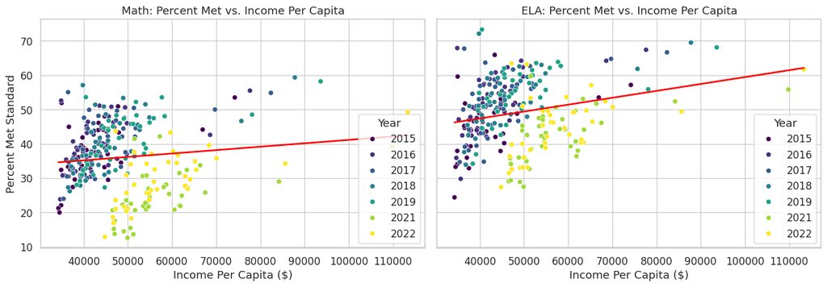

```python
def plot_income_vs_percent(merged_data):
    """
    Given the merged data frame, this function creates two plots
    (one for math standard and another for ELA standard testing scores)
    with income on the x-axis and percent met standard on the y-axis.
    The plots also contain a line of best fit to visualize the relationship
    between the two variables.
    """
    sns.set(style="whitegrid", font_scale=1.1)

    fig, axes = plt.subplots(ncols=2, figsize=(14, 5), sharey=True)

    for ax, subj in zip(axes, ["Math", "ELA"]):
        subset = merged_data[merged_data["TestSubject"] == subj]
        sns.scatterplot(x="IncomePerCapita",
                        y="PercentMetStandard",
                        hue="Year",
                        palette="viridis",
                        data=subset,
                        ax=ax,
                        legend="full")
        sns.regplot(x="IncomePerCapita",
                    y="PercentMetStandard",
                    data=subset,
                    scatter=False,
                    line_kws={"color": "red", "linewidth": 2},
                    ci=None,
                    ax=ax)
        ax.set_title(subj + ": Percent Met vs. Income Per Capita")
        ax.set_xlabel("Income Per Capita ($)")
        ax.set_ylabel("Percent Met Standard")

    plt.tight_layout()

# Check for expected test subjects.
expected_subjects = {"Math", "ELA"}
actual_subjects = set(merged_data["TestSubject"])
actual_subjects.remove(np.nan)
assert expected_subjects == actual_subjects, ("Expected at least these test subjects:",
                                             expected_subjects, "but found: ", actual_subjects)
# Check for the number of data points.
for subj in ["Math", "ELA"]:
    subset = merged_data[merged_data["TestSubject"] == subj]
    points = subset[["IncomePerCapita", "PercentMetStandard"]].dropna()
    assert len(points) == 273, (
        "Not all data points to plot for", subj, "are being plotted"
            )

plot_income_vs_percent(merged_data)
```

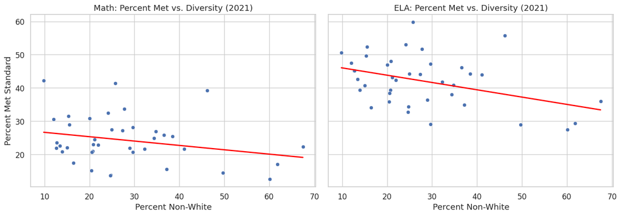

```python
def plot_diversity_vs_percent(merged_data):
    """
    Given the merged data frame, this function creates two plots
    (one for math standard and another for ELA standard testing scores)
    with diversity on the x-axis and percent met standard on the y-axis.
    The plots also contain a line of best fit to visualize the relationship
    between the two variables.
    """
    fig, axes = plt.subplots(ncols=2, figsize=(14, 5), sharey=True)

    for ax, subj in zip(axes, ["Math", "ELA"]):
        subset = merged_data[merged_data["TestSubject"] == subj]
        sns.scatterplot(x="% Diversity",
                        y="PercentMetStandard",
                        data=subset,
                        ax=ax)
        sns.regplot(x="% Diversity",
                    y="PercentMetStandard",
                    data=subset,
                    scatter=False,
                    line_kws={"color": "red", "linewidth": 2},
                    ci=None,
                    ax=ax)
        ax.set_title(subj + ": Percent Met vs. Diversity (2021)")
        ax.set_xlabel("Percent Non‐White")
        ax.set_ylabel("Percent Met Standard")

    plt.tight_layout()


# Check for expected test subjects.
expected_subjects = {"Math", "ELA"}
actual_subjects = set(merged_data["TestSubject"])
actual_subjects.remove(np.nan)
assert expected_subjects == actual_subjects, ("Expected at least these test subjects:",
                                             expected_subjects, "but found: ", actual_subjects)
# Check for the number of data points.
for subj in ["Math", "ELA"]:
    subset = merged_data[merged_data["TestSubject"] == subj]
    points = subset[["% Diversity", "PercentMetStandard"]].dropna()
    assert len(points) == 39, (
        "Not all data points to plot for", subj, "are being plotted"
            )

plot_diversity_vs_percent(merged_data)
```

```python
def test_normality(merged_data):
    """
    Given the merged data frame, this function calculates and
    prints whether each variable follows a normal distribution or not.
    """
    for subj in ["Math", "ELA"]:
        print(subj)
        subset = merged_data[merged_data["TestSubject"] == subj].dropna()

        for column in ["IncomePerCapita", "% Diversity", "PercentMetStandard"]:
            data = subset[column]
            stat, p = shapiro(data)
            print(column, '(not normal)' if p < 0.05 else '(normal)')


test_normality(merged_data)
```

```
Math
IncomePerCapita (not normal)
% Diversity (not normal)
PercentMetStandard (not normal)
ELA
IncomePerCapita (not normal)
% Diversity (not normal)
PercentMetStandard (normal)
```

```python
def stats(merged_data):
    """
    Given the merged data frame, this function calculates and
    prints the r and p values for the relationship between
    diversity and percent met standard as well as income and
    percent met standard for each subject.
    """
    for subj in ["Math", "ELA"]:
        subset = merged_data[merged_data["TestSubject"] == subj]
        subset = subset.dropna(subset=["% Diversity"])
        r_income, p_income = pearsonr(subset["IncomePerCapita"],
                                      subset["PercentMetStandard"])
        r_div, p_div = pearsonr(subset["% Diversity"], subset["PercentMetStandard"])
        print("----", subj, "----")
        print("Income vs. Score:    r = ", r_income.round(3), ", p = ", p_income.round(3))
        print("Diversity vs. Score: r = ", r_div.round(3), ", p = ", p_div.round(3))
        print()

stats(merged_data)
```

```
---- Math ----
Income vs. Score:    r =  0.547 , p =  0.0
Diversity vs. Score: r =  -0.255 , p =  0.117

---- ELA ----
Income vs. Score:    r =  0.561 , p =  0.0
Diversity vs. Score: r =  -0.403 , p =  0.011
```

```python
def spearman_stats(merged_data):
    """
    Given the merged data frame, this function calculates and
    prints the Spearman correlation (rho and p-value) between
    IncomePerCapita and PercentMetStandard, as well as % Diversity
    and PercentMetStandard for Math and ELA separately.
    """
    for subj in ["Math", "ELA"]:
        subset = merged_data[merged_data["TestSubject"] == subj].dropna(
            subset=["IncomePerCapita", "% Diversity", "PercentMetStandard"]
        )

        rho_income, p_income = spearmanr(subset["IncomePerCapita"], subset["PercentMetStandard"])
        rho_div, p_div = spearmanr(subset["% Diversity"], subset["PercentMetStandard"])

        print("---- ", subj, "----")
        print("Spearman Income vs. Score:    ρ = ", rho_income.round(3), "p = ", p_income.round(3))
        print("Spearman Diversity vs. Score: ρ = ", - rho_div.round(3), "p = ", p_div.round(3))
        print()

spearman_stats(merged_data)
```

```
----  Math ----
Spearman Income vs. Score:    ρ =  0.671 p =  0.0
Spearman Diversity vs. Score: ρ =  0.196 p =  0.231

----  ELA ----
Spearman Income vs. Score:    ρ =  0.622 p =  0.0
Spearman Diversity vs. Score: ρ =  0.326 p =  0.043
```

### Analysis

To analyze the plots using statistical methods, we initally intended to use Pearson's r value (correlation coefficient) to measure the strength and direction of a linear relationship between income and testing success as well as diversity and testing success. R values range from -1 (a strong negative correlation) to +1 (a strong positive correlation). The closer the r value is to 0, the weaker the relationship is. Generally, when an r value greater than 0.5 is considered statistically significant. The p value indicates how likely it is to obtain a result at least as extreme as the result you actually observe. In a nutshell, a p value less than 0.05 indicates statistical significance and that your correlation is unlikely due to chance. However, Pearson's correlation test assumes that the distribution of variables is approximately a normal distribution. When variables do not follow this normal distribution, the calculated p values may be inaccurate or misleading. As we can see, almost all the variables for Math and ELA testing do not follow a normal distribution.

Consequently, we pivoted to using the Spearman Rank Correlation test, which is better suited for non-normally distributed data. It simply describes the monotonic relationship between two variables. A rho value between 0 and 0.40 generally means weak to no correlation, one between 0.40 and 0.60 means a moderately strong correlation, and one above 0.60 means a strong or even very strong correlation. The p value in the Spearman Rank Correlation test tests the null hypothesis (the assumption that there is no correlation between the variables). If the p value is less than 0.05, this means the results are statistically significant.

# RQ#2: Has the difference in test scores between the richest and poorest counties increased or decreased over time?

We will use the years 2015-2022 since those are the only years we have for the test scores data. For the richest and poorest counties, we will use the top and bottom 5.

```python
# Finding the richest and poorest counties.
poorest = income.loc[2015:2022].groupby(level="Year").apply(lambda x:x.nsmallest(5, "IncomePerCapita"))
poorest = poorest.droplevel(0)

richest = income.loc[2015:2022].groupby(level="Year").apply(lambda x:x.nlargest(5, "IncomePerCapita"))
richest = richest.droplevel(0)

assert len(poorest.loc[2015:2022,:]["IncomePerCapita"].tolist()) == 40
assert len(richest.loc[2015:2022,:]["IncomePerCapita"].tolist()) == 40
```

```python
# Merging the poorest and richest data with the scores data.
merge = merged_data.loc[2015:2022, "TestSubject":"PercentMetStandard"]
poorest = merge.merge(poorest, on=["Year", "County"])
richest = merge.merge(richest, on=["Year", "County"])
poorest = poorest.reset_index()
richest = richest.reset_index()

assert poorest.columns.tolist() == ['Year', 'County', 'TestSubject', 'PercentMetStandard', 'IncomePerCapita']
assert richest.columns.tolist() == ['Year', 'County', 'TestSubject', 'PercentMetStandard', 'IncomePerCapita']
```

```python
# Creating new subsets of the poorest and richest datasets based on subject.
poorest_ELA = poorest[poorest["TestSubject"] == "ELA"]
richest_ELA = richest[richest["TestSubject"] == "ELA"]
poorest_math = poorest[poorest["TestSubject"] == "Math"]
richest_math = richest[richest["TestSubject"] == "Math"]

assert (poorest_ELA[poorest_ELA["County"] == "Stevens"]["PercentMetStandard"].tolist() ==
    [33.3, 47.1, 50.0, 51.0, 54.8, 34.1, 36.4])
assert (richest_ELA[richest_ELA["County"] == "Snohomish"]["PercentMetStandard"].tolist() ==
    [51.9, 59.6, 57.6, 60.5, 62.7, 46.1, 50.7])
```

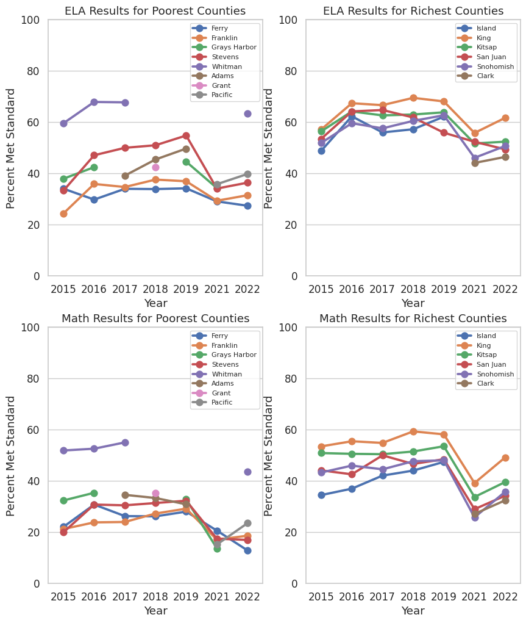

```python
# Graphing the results for both income groups over time for both subjects.
fig, [[ax1, ax2], [ax3, ax4]] = plt.subplots(2, 2, figsize=(10, 12))
titles = ["ELA Results for Poorest Counties",
          "ELA Results for Richest Counties",
          "Math Results for Poorest Counties",
          "Math Results for Richest Counties"]
axes = [ax1, ax2, ax3, ax4]
data_sets = [poorest_ELA, richest_ELA, poorest_math, richest_math]

for ax, title, data in zip(axes, titles, data_sets):
    sns.pointplot(ax=ax, data=data, x="Year", y="PercentMetStandard", hue="County")
    ax.set_ylim(0, 100)
    ax.set_title(title)
    ax.legend(fontsize=8)
    ax.grid(True, axis="y")
    ax.set_ylabel("Percent Met Standard")
```

### Analysis

From these graphs, a few observations can be made.

With the main exception of Whitman county, the richest counties generally have higher results in both subjects over all the years. The top 3 for the poorest counties changes often while the richest counties is generally consistent.

In contrast, while the poorest counties did not see as much of a drastic decline in scores after 2020 compared to the richest, that could be more because the results were originally lower, not because of a particularly high-quality online school system. In 2022 with the return of in-person school, the poorest counties do not make much of a recovery, with the scores staying generally the same as the 2021 results. Lack of funding could have made making a recovery more difficult.

To see if the difference in results between the poorest and richest has changed over time, it would be clearer to graph the median results against each other.

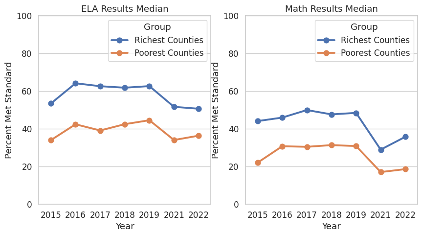

```python
# Graphing the means.
poorest_ELA_med = poorest_ELA.groupby("Year")[["PercentMetStandard"]].median()
poorest_math_med = poorest_math.groupby("Year")[["PercentMetStandard"]].median()
richest_ELA_med = richest_ELA.groupby("Year")[["PercentMetStandard"]].median()
richest_math_med = richest_math.groupby("Year")[["PercentMetStandard"]].median()

poorest_ELA_med["Group"] = "Poorest Counties"
poorest_math_med["Group"] = "Poorest Counties"
richest_ELA_med["Group"] = "Richest Counties"
richest_math_med["Group"] = "Richest Counties"

ELA_med = pd.concat([richest_ELA_med, poorest_ELA_med])
math_med = pd.concat([richest_math_med, poorest_math_med])

fig, [ax1, ax2] = plt.subplots(1, 2, figsize=(10, 5))
axes = [ax1, ax2]
data_sets = [ELA_med, math_med]
titles = ["ELA Results Median", "Math Results Median"]

for ax, data, title in zip(axes, data_sets, titles):
    sns.pointplot(ax=ax, data=data, x="Year", y="PercentMetStandard", hue="Group")
    ax.set_ylim(0, 100)
    ax.set_title(title)
    ax.grid(True, axis="y")
    ax.set_ylabel("Percent Met Standard")
```

### Analysis

This means that the answer to RQ#2 is no, the gap between the richest and poorest counties has not increased or decreased significantly over time. Although the gap has not widened, this does not mean there is no need for concern. The fact that there is a large gap in the first place between the two groups is a big issue as it is indicative of economic inequality negatively impacting student results. In addition, schools need more support after the decrease in scores after Covid-19 to get back to levels prior to 2020. This is especially true with math as the passing percentage is consistently far lower compared to ELA.

# RQ#3: How wealthy does a county have to be in order to have the majority of students meet testing standards?

For the purposes of this question, we will define a "majority" to be at least 50% of students meeting testing standards. We will use linear regression for both the ELA and the math data. We will be trying to predict the passing percentages based on income per capita and will use data from the most recent year available for both income and test scores, 2022. We are not using the previous years for the income data because the income per capita will be steadily increasing due to inflation.

```python
# Filtering the data for the relevant columns.
data = merged_data.loc[2022, ("IncomePerCapita", "TestSubject", "PercentMetStandard")]
```

```
ELA Line error: 5.835347568209465
Math Line error: 4.042592691964382
```

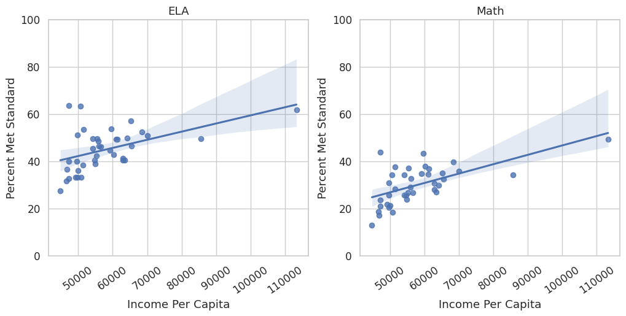

```python
# Setting up the linear regression model for each subject.
fig, [ax1, ax2] = plt.subplots(1, 2, figsize=(12, 5))

subjects = ["ELA", "Math"]
axes = [ax1, ax2]

for ax, subj in zip(axes, subjects):
    subject_data = data[data["TestSubject"] == subj]
    subject_data = subject_data.drop(columns="TestSubject")
    subject_data["PercentMetStandard"] = subject_data["PercentMetStandard"].astype(float)

    X = subject_data[["IncomePerCapita"]]
    y = subject_data["PercentMetStandard"]
    X_train, X_test, y_train, y_test = train_test_split(X, y, test_size=0.2, random_state=50)
    print(f'{subj}'+ " Line error:",
          root_mean_squared_error(y_test, LinearRegression().fit(X_train, y_train).predict(X_test)))

    sns.regplot(ax=ax, data=subject_data, x="IncomePerCapita", y="PercentMetStandard")
    ax.set_ylim(0, 100)
    ax.set_title(subj)
    ax.tick_params(axis="x", rotation=35)
    ax.set_ylabel("Percent Met Standard")
    ax.set_xlabel("Income Per Capita")
    assert len(subject_data["IncomePerCapita"].tolist()) == 39
```

### Analysis

From the ELA graph, a 50% percentage passing corresponds to an income per capita of about 70,000. From the math graph, it corresponds to an income per capita of about 105,000.

However, looking at the distribution of the data points in both graphs, these results may not be accurate predictions. While the error rate is not particularly high for either subject, most of the data points are in an income per capita range of between 50,000-70,000. There are only two counties that make more than that, with one county making significantly more, around 115,000. Since there are only two counties above that income range, it could be inaccurate to extrapolate beyond the 50,000-70,000 income range.

For the ELA results, there are multiple counties that have a majority of students meet standard, including a few that are on the lower end of income. In addition, there is a variation in the percentage met standard of about 30% just within the counties that have an income per capita of less than 50,000. This strongly suggests that while there is a gap in results between the very richest and poorest counties, income per capita may not be a great predictor of student results on its own and instead should be just one of many factors that could be used to predict.

A similar variation can be seen in the math results, implying the same thing. For the math results in particular, this prediction may not be accurate because when looking at the graphed data, while a few got close, there was no county that had a majority of its students meet standard. Math scores have generally always been lower than ELA results and have also been lowered post-Covid as well. Since the data used is from 2022, many counties probably have not made a full academic recovery from Covid. The fact that math scores are so low across all counties, including those with a higher income, points to a deeper systemic issue with math education in general.

# Implications

Our analysis explored how two key factors, income per capita and racial/ethnic diversity, relate to standardized test performance in Washington state. Specifically, we analyzed the relationship between these variables and the percentage of students meeting grade-level standards in Math and English Language Arts (ELA) via the Smarter Balanced assessment (SBAC).

### Who might benefit from this analysis?

- Policymakers could use this analysis to better allocate funding and support to schools in counties with lower test scores or have not made a recovery from Covid.
- School administrators could use this data to make targeted interventions. Using socioeconomic and demographic contexts for students, they could provide more resources and help for certain students, potentially improving test scores and general academic performance.
- Scholarship organizations can prioritize offering financial help to students in areas with less income

### Who might be excluded or harmed?

- Students from underrepresented or disadvantaged backgrounds may be unfairly characterized by numbers and statistics, reinforcing stereotyped and inaccurate narratives/assumptions if interpreted incorrectly. While the data analysis can provide a county level overview, it does not acknowledge potential disparities within counties. Within a county with a high income per capita, there could be a high level of economic and academic inequality which is obscured by the data analysis process. There is data lost when trying to get a bigger picture of a problem.
- Schools and counties with high diversity might be stigmatized if correlations are misunderstood as causal relationships rather than reflections of systemic inequities or indicators of other societal issues. If this data is taken out of context, it could be used as a weapon against diversity instead of a tool for improving student success.
- Since the SBAC tests are in English, counties with a higher proportion of English learners may have lower results.
- Private schools are not included in this dataset since they may not partake in standardized testing.
- Very small schools were not included in the data due to the suppression rules from the scores dataset due to student privacy laws.

# Limitations

### Correlation Does Not Mean Causation

For our statistical analysis, we used Pearson and Spearman correlation tests/values to describe associations between the variables we were testing. These do not necessarily mean that income or diversity are causal mechanisms. Although statistical analysis factors in the possibility of correlation due to chance, it is important to remember that the two variables being compared are not necessarily directly related.

### Outside Factors

Many factors play into how well a child does in standardized testing. Variables like parental education, school funding, teacher qualifications, student-faculty ratios, and so much more all play into student testing outcomes. For this project, we simply tested two large factors, income and diversity. These are certainly influential, but it is important to remember that there are countless other confounding variables that play into academic success.

### Covid-19

From the multiple graphs across the analysis. It is clear that Covid-19 negatively impacted test scores across all of Washington state. It is likely that even with data a couple years after Covid from 2022, there are still lingering effects reflected in the test scores. These effects could have affected the accuracy of our analysis or obscured other trends in the scores.

# Considerations for Future Work

### Wider Scope

Our work in this project could be used as a framework for similar analysis done in other states or on a larger scale. It is clear that there is education disparity in Washington, but we do not know how Washington compares to other states. It could be insightful to do this type of project across all 50 states to see which states need the most improvement and which states could provide an example of how to reduce education inequality.

In addition, we used results from the SBAC testing, but many schools also offer other forms of standardized testing, like the WCAS or AIM. Looking at different types of standardized testing and comparing their results against each other could reveal if certain score trends and correlations are universal across all tests or just specific to one type.

### More Factors

We focused on income and diversity in this project, but test scores and academic achievement in general are extremely complex topics that cannot be attributed to only two variables. Some other things that could be taken into account as factors include county population, the urban vs rural divide, school sizes, access to technology, and amount of spending per student. Even intangible factors like school culture or levels of teacher/student engagement can contribute. Any of these other variables could be a stronger predictor of student testing results.

### More Post-Covid Data

The most recent scores data we used was from 2022 and it was still affected by Covid. While the data from 2022 showed that many counties are slowly returning to pre-Covid test results, we cannot be sure that recovery with be a quick or linear process without actually looking at data from 2023 and beyond.